# 회귀분석의 이해

데이터에 가장 좋은 선 긋기 — 원자력 안전기술원 특강

2026-08-12

## 왜 ‘내가’ 회귀분석을 알아야 할까요?

연구 현장에서 매일 만나는 세 장면:

- **장면 1 — 계측기 검교정**: 기준값과 계측기 읽음값을 나란히 놓고 **보정 곡선**을 긋는 일
- **장면 2 — 용량-반응 관계**: 노출량이 변할 때 반응이 **어떻게, 얼마나** 변하는지 정리하는 일
- **장면 3 — 성능 저하 추세**: 시간에 따른 설비·재료의 열화를 선으로 요약해 **앞날을 내다보는** 일
- 세 장면의 공통점: **변수 사이의 관계를 선으로 요약**하는 것 — 이것이 바로 회귀분석입니다

## 오늘의 여정 — 아홉 개의 정거장

Nine chapters in one view: today’s lecture roadmap

| Stage | Ch. | Topic |
| --- | --- | --- |
| 기초 다지기 | 1–2 | 회귀분석이란 무엇인가 / 기초 행렬 이론 |
| 직선 긋기 | 3–4 | 단순선형회귀 / 다중선형회귀 |
| 점검하기 | 5–6 | 회귀진단 및 보정 / 모형 비교와 변수선택 |
| 현장 적용 | 7 | 사례분석: 아이스크림 판매량 예측 |
| **오늘의 핵심** | **8** | **가중회귀 — 측정 정밀도를 모형에 반영하는 법** |
| 확장 | 9 | 가변수 — 범주 정보를 모형에 넣는 법 |

- 1장~7장과 9장은 **아이스크림 가게 이야기** 하나로 이어집니다
- 8장 **가중회귀**가 이 특강의 핵심 목적지입니다

## 오늘의 주인공 — 아이스크림 가게 사장님

- 사장님의 고민: **“다음 기간엔 아이스크림이 얼마나 팔릴까?”**
- 손에 쥔 자료: 4주 단위 **30개 기간**의 판매 기록 (CNU 회귀분석 강의노트 7장의 ice cream 자료)
- 이 한 가지 이야기로 1~7장과 9장의 개념을 꿰어 갑니다 (8장은 측정 불확도가 기록된 physics 자료 사용)

## 세 가지 수업 약속

- **약속 1**: 모든 수식은 기호를 **하나하나** 한국어로 풀어 설명합니다 — 설명 없는 수식은 없습니다
- **약속 2**: 새 개념은 **비유와 그림이 먼저**, 수식은 그다음에 나옵니다
- **약속 3**: 어려우면 **언제든 손을 들어 주세요** — 질문은 강의를 늦추는 것이 아니라 완성합니다

# 제1장 서론 — 회귀분석이란 무엇인가

## 어느 아이스크림 가게 사장님의 고민

- 사장님의 장부: 지난 30개 기간(4주 단위)의 **판매량**과 함께 **온도, 가격, 소득** 기록
- 일기예보: “다음 주는 유난히 덥겠습니다”
- 고민: *“그럼 아이스크림을 몇 통이나 준비해야 하지?”*
- 감(感)이 아니라 **기록(데이터)** 으로 답하는 방법 → 오늘 배울 **회귀분석**
- 이 가게 이야기가 특강 전체(제1~7장, 제9장)를 관통합니다

## 회귀분석: 점 구름 사이로 가장 좋은 직선 긋기

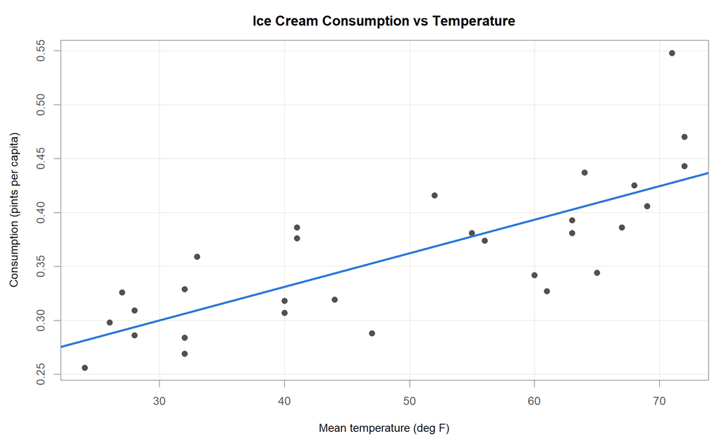

Ice cream consumption vs temperature with the fitted least-squares line

$$\hat{y}_i = 0.2069 + 0.003107\, x_i$$

여기서 $\hat{y}_i$는 $i$번째 기간의 아이스크림 소비량 예측값(적합값), $x_i$는 그 기간의 평균 온도, $0.2069$는 직선의 절편 추정값 $\hat\beta_0$, $0.003107$은 기울기 추정값 $\hat\beta_1$입니다.

**한 줄 요약**: 회귀분석 = 점 구름의 경향을 **하나의 선**으로 요약하는 방법.

Fitted by lm(IC ~ temp), n = 30, R-squared = 0.602. Numbers computed by code/agent/2026-08-11/make-lecture-figures.R

## “회귀(regression)”라는 이름의 유래 — Galton (1886)

- 골턴(Galton)은 **아버지 키와 아들 키**의 관계를 연구
- 키가 매우 큰 아버지의 아들: 크긴 하지만 아버지만큼 **극단적이지는 않음**
- 키가 매우 작은 아버지의 아들: 역시 **평균 쪽으로** 이동
- 이 현상을 “평균으로의 회귀(regression towards mediocrity)”라 이름 붙임
- 오늘날의 회귀분석: 이름은 여기서 왔지만, **변수 사이의 관계를 선(함수)으로 요약하는 방법 전반**을 뜻함

Galton, F. (1886). Regression towards mediocrity in hereditary stature. *Journal of the Anthropological Institute*, 15, 246-263.

## 용어 정리: 모형 = 신호 + 잡음

비유: **계측기 지시값 = 참값(신호) + 측정오차(잡음)**. 데이터도 마찬가지입니다.

$$y = f(x) + \varepsilon$$

여기서 $y$는 반응변수(알고 싶은 결과), $x$는 설명변수(결과를 설명하는 단서), $f(x)$는 신호(두 변수 사이의 체계적 관계), $\varepsilon$은 잡음(우연한 흔들림, 오차)입니다.

- **반응변수** $y_i$: 알고 싶은 값 — 예) $i$번째 기간의 아이스크림 소비량 IC
- **설명변수** $x_i$: 단서가 되는 값 — 예) 그 기간의 온도 temp
- **오차** $\varepsilon_i$: 평균 0, 분산 $\sigma^2$의 우연한 흔들림
- $f(x)$를 직선 $\beta_0 + \beta_1 x$로 택하면 → 제3장의 **단순선형회귀**

## 회귀로 답할 수 있는 세 가지 질문

1. **설명(explanation)**: 온도는 판매량과 얼마나 강하게, 어느 방향으로 관련되는가?
2. **예측(prediction)**: 다음 기간의 온도가 주어지면, 판매량은 얼마쯤일까?
3. **조정(adjustment)**: 가격·소득이 같다고 놓았을 때, **온도만의** 효과는 얼마인가?

일반적 활용 예 (연구 현장): 계측기 **검교정 곡선**(표준 입력 대 지시값의 관계로 지시값 보정), 설비 상태 지표의 **시간 추세** 파악 등.

**한 줄 요약**: 하나의 적합직선으로 **설명·예측·조정** 세 가지 질문에 모두 답할 수 있다.

## 특강을 관통하는 데이터: ice cream

Variables in the ice cream data (CNU regression lecture note, Ch. 7; n = 30 four-week periods)

| Variable | Role | Description |
| --- | --- | --- |
| IC | response $y_i$ | ice cream consumption |
| price | explanatory | price of ice cream |
| income | explanatory | family income |
| temp | explanatory | mean temperature |
| year | explanatory (indicator) | year-of-observation indicator (0/1/2) |

```r
# Ice cream data: 30 four-week periods (CNU lecture note, Chapter 7)
head(ice)                         # columns: IC, price, income, temp, year

# Preview of our first regression (details in Chapter 3)
fit <- lm(IC ~ temp, data = ice)  # intercept 0.2069, slope 0.003107
```

Numbers computed by code/agent/2026-08-11/make-lecture-figures.R

# 제2장 기초 행렬 이론 — 데이터를 한 덩어리로 다루기

## 왜 행렬인가 — 성적표를 한 장씩 넘기지 않기

- 비유: 학생 30명의 성적 처리 — 성적표를 **한 장씩** 넘기며 계산할까요, **엑셀 시트 통째로** 계산할까요?
- 아이스크림 가게 자료도 결국 표 한 장: 30개 기간 $\times$ 4개 항목(소비량 IC, 가격 price, 소득 income, 온도 temp)
- 기간마다 회귀식을 따로 쓰면 같은 모양의 식이 30줄 필요:

$$y_1=\beta_0+\beta_1 x_{11}+\cdots+\varepsilon_1,\qquad
y_2=\beta_0+\beta_1 x_{21}+\cdots+\varepsilon_2,\qquad
\dots,\qquad
y_{30}=\beta_0+\beta_1 x_{30,1}+\cdots+\varepsilon_{30}$$

여기서 $y_i$는 $i$번째 기간의 반응변수(아이스크림 소비량), $x_{i1}$은 $i$번째 기간의 첫 번째 설명변수 값, $\beta_0,\beta_1,\dots$는 모든 기간에 공통인 회귀계수, $\varepsilon_i$는 $i$번째 기간의 오차, 관측 수는 $n=30$입니다.

- **행렬 = 묶음 포장 도구**: 이 30줄을 단 한 줄로 줄여 줍니다

## 벡터와 행렬 — 딱 세 가지 표기만 기억하기

- **벡터**: 숫자를 세로로 줄 세운 것 $\to$ 굵은 소문자 $\mathbf{y}$
- **행렬**: 숫자를 격자(표) 모양으로 배열한 것 $\to$ 굵은 대문자 $\mathbf{X}$
- **원소와 차원**: $x_{ij}$는 $i$행 $j$열의 숫자, 차원은 “행 $\times$ 열” — **행 먼저, 열 나중**

$$\mathbf{y}=\begin{pmatrix} y_1\\ y_2\\ \vdots\\ y_{30} \end{pmatrix}
\;(30\times 1), \qquad
\mathbf{X}=\begin{pmatrix}
x_{11} & \cdots & x_{1p}\\
\vdots & \ddots & \vdots\\
x_{n1} & \cdots & x_{np}
\end{pmatrix}
\;(n\times p)$$

여기서 $\mathbf{y}$는 반응변수 $y_1,\dots,y_{30}$을 세로로 모은 벡터, $\mathbf{X}$는 설명변수 값들을 모은 행렬, $x_{ij}$는 $i$번째 관측의 $j$번째 설명변수 값, $n$은 관측 수, $p$는 설명변수의 개수입니다.

- 회귀에서는 절편용 1열을 맨 앞에 붙여 $n\times(p+1)$ 행렬로 씁니다 — 다음 슬라이드의 $30\times 4$ 모형행렬이 그 예입니다
- 한 줄 요약: 굵은 글씨를 만나면 “숫자 여러 개를 한 덩어리로 묶었구나”라고 읽으면 됩니다

## 회귀모형의 행렬 표현 — $\mathbf{y}=\mathbf{X}\boldsymbol{\beta}+\boldsymbol{\varepsilon}$

$$\underbrace{\begin{pmatrix} y_1\\ y_2\\ \vdots\\ y_{30} \end{pmatrix}}_{\mathbf{y}\;(30\times 1)}
=
\underbrace{\begin{pmatrix}
1 & x_{11} & x_{12} & x_{13}\\
1 & x_{21} & x_{22} & x_{23}\\
\vdots & \vdots & \vdots & \vdots\\
1 & x_{30,1} & x_{30,2} & x_{30,3}
\end{pmatrix}}_{\mathbf{X}\;(30\times 4)}
\underbrace{\begin{pmatrix} \beta_0\\ \beta_1\\ \beta_2\\ \beta_3 \end{pmatrix}}_{\boldsymbol{\beta}\;(4\times 1)}
+
\underbrace{\begin{pmatrix} \varepsilon_1\\ \varepsilon_2\\ \vdots\\ \varepsilon_{30} \end{pmatrix}}_{\boldsymbol{\varepsilon}\;(30\times 1)}$$

여기서 $\mathbf{y}$는 30개 기간의 아이스크림 소비량(IC)을 모은 반응변수 벡터, $\mathbf{X}$의 1열은 절편 $\beta_0$의 자리를 만들어 주는 1들이고 2, 3, 4열은 각각 가격(price) $x_{i1}$, 소득(income) $x_{i2}$, 온도(temp) $x_{i3}$, $\boldsymbol{\beta}$는 회귀계수 벡터, $\boldsymbol{\varepsilon}$는 오차 벡터(각 $\varepsilon_i$의 분산은 $\sigma^2$)입니다.

- $\mathbf{X}$의 **1열은 전부 1**: 절편 $\beta_0$이 모든 기간에 똑같이 더해지도록 하는 자리
- 행렬 곱 규칙은 “행과 열을 짝지어 곱해서 더하기” — 그 결과가 앞 슬라이드의 30줄과 정확히 같음<sup>1</sup>
[^1]: Matrix formulation follows the CNU regression lecture note (Ch. 2) and Kutner et al. (2005), *Applied Linear Statistical Models*, 5th ed.

## 전치와 역행렬 — “뒤집기”와 “되돌리기”

- **전치** $\mathbf{X}^\top$: 행과 열을 맞바꾸기 = 표를 대각선 축으로 **뒤집기** ($30\times 4 \to 4\times 30$)
- **역행렬** $\mathbf{A}^{-1}$: 곱하면 원래대로 **되돌리는** 행렬 — 나눗셈의 행렬 버전
- 숫자 비유: $3x=6$이면 $x=\tfrac{1}{3}\times 6=2$ $\to$ 행렬에서는 $\mathbf{A}\mathbf{x}=\mathbf{b}$이면 $\mathbf{x}=\mathbf{A}^{-1}\mathbf{b}$

$$\mathbf{A}^{-1}\mathbf{A}=\mathbf{I}$$

여기서 $\mathbf{A}$는 정사각(행 수 = 열 수) 행렬, $\mathbf{A}^{-1}$은 $\mathbf{A}$의 역행렬, $\mathbf{I}$는 대각선만 1이고 나머지는 0인 항등행렬(숫자 1의 행렬 버전)입니다.

```r
# Transpose and inverse in R
t(X)             # transpose: flip rows and columns
solve(A)         # inverse of a square matrix A ("undo" matrix)
solve(A) %*% A   # returns the identity matrix I
```

- 한 줄 요약: 전치는 뒤집기, 역행렬은 되돌리기 — 이 두 가지로 다음 슬라이드에서 회귀를 다 풉니다

## 예고편 — 한 줄이면 모든 회귀가 풀린다

$$\hat{\boldsymbol{\beta}}=(\mathbf{X}^\top\mathbf{X})^{-1}\mathbf{X}^\top\mathbf{y}$$

여기서 $\hat{\boldsymbol{\beta}}$는 자료로 추정한 회귀계수 벡터(위에 붙은 모자 기호는 “추정값”이라는 뜻), $\mathbf{X}^\top$은 $\mathbf{X}$의 전치, $(\mathbf{X}^\top\mathbf{X})^{-1}$은 $\mathbf{X}^\top\mathbf{X}$의 역행렬, $\mathbf{y}$는 반응변수 벡터입니다.

```r
# Chapter 4 preview: all of least-squares regression in one line
X <- model.matrix(IC ~ price + income + temp, data = ice)  # 30 x 4, first column all 1s
y <- ice$IC

beta_hat <- solve(t(X) %*% X) %*% t(X) %*% y   # (X'X)^{-1} X'y
# identical to coef(lm(IC ~ price + income + temp, data = ice))
```

- 단순회귀·다중회귀·가변수회귀 모두 이 **한 줄**의 특수한 경우 (이 식은 제4장에서 다시 만납니다)
- 아이스크림 자료에 넣으면 $\hat\beta_0=0.193$, $\hat\beta_1=-1.029$(price), $\hat\beta_2=0.00331$(income), $\hat\beta_3=0.00346$(temp)<sup>1</sup>
- 한 줄 요약: 오늘 배운 전치와 역행렬만 있으면 회귀분석의 심장부를 읽을 수 있습니다
[^2]: Computed by code/agent/2026-08-11/make-lecture-figures.R

# 제3장 단순선형회귀 — 가장 좋은 직선 하나 긋기

## 어떤 직선이 “가장 좋은” 직선일까?

- 산점도 위에 자를 대고 그으면 **사람마다 다른 직선**이 나옵니다
- 상상: 각 점과 막대기(직선)를 **용수철**로 연결
- 용수철에 저장되는 에너지는 늘어난 길이의 **제곱**에 비례
- 막대기는 용수철 에너지의 합이 **최소**가 되는 자리에서 멈춤
- 그 멈춘 자리가 바로 **최소제곱(least squares) 직선**

## 잔차: 점과 직선 사이의 수직 간격

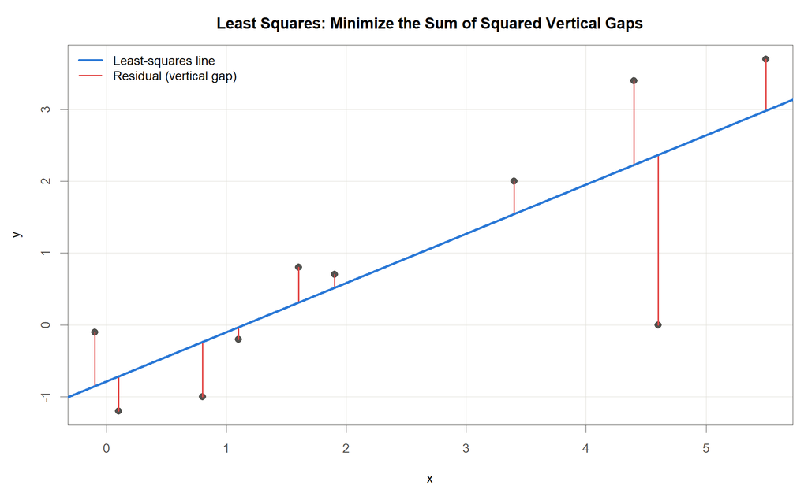

Least squares minimizes the sum of squared vertical gaps

$$e_i = y_i - \hat y_i$$

여기서 $e_i$는 $i$번째 잔차(그림의 빨간 수직 선분, 부호 포함), $y_i$는 실제 관측값, $\hat y_i$는 직선이 알려 주는 적합값(예측값)입니다.

## 최소제곱법: 제곱 합이 가장 작은 직선

모형: $y_i = \beta_0 + \beta_1 x_i + \varepsilon_i$ — 여기서 $y_i$는 반응변수, $x_i$는 설명변수, $\beta_0$는 절편, $\beta_1$은 기울기, $\varepsilon_i$는 오차(분산 $\sigma^2$), $i=1,\dots,n$입니다.

$$\min_{\beta_0,\beta_1}\; \sum_{i=1}^{n} \left( y_i - \beta_0 - \beta_1 x_i \right)^2$$

여기서 괄호 안은 $i$번째 점과 직선 사이의 수직 간격이고, 이 제곱 합을 가장 작게 만드는 $\beta_0, \beta_1$을 찾는 것이 최소제곱법입니다.

- 이 방법의 정식 명칭은 **보통최소제곱**(Ordinary Least Squares, OLS)입니다

## 최소제곱법의 해: 기울기와 절편 공식

$$\hat\beta_1 = \frac{S_{xy}}{S_{xx}}, \qquad \hat\beta_0 = \bar y - \hat\beta_1 \bar x$$

$$S_{xy} = \sum_{i=1}^{n}(x_i-\bar x)(y_i-\bar y), \qquad S_{xx} = \sum_{i=1}^{n}(x_i-\bar x)^2$$

여기서 $\hat\beta_0, \hat\beta_1$은 최소제곱 추정량, $\bar x, \bar y$는 각각 $x, y$의 표본평균, $S_{xy}$는 $x$와 $y$가 함께 움직이는 정도, $S_{xx}$는 $x$ 자체의 흩어짐입니다.

Least squares estimation: Kutner et al. (2005), *Applied Linear Statistical Models*, 5th ed.; CNU regression lecture note, Ch. 3.

## 기울기와 절편이 말해 주는 것

- $\hat\beta_1$ (기울기): $x$가 1단위 커질 때 $y$가 **평균적으로** 변하는 양
- $\hat\beta_0$ (절편): $x=0$일 때 예측되는 $y$의 평균 — $x=0$이 자료 범위 밖이면 해석에 주의

아이스크림 자료($y$ = 소비량 IC, $x$ = 온도 temp)의 적합 결과:

$$\hat y = 0.2069 + 0.003107\, x$$

여기서 $\hat y$는 예측된 아이스크림 소비량, $x$는 온도이며, 기울기 0.003107은 온도가 1도 오를 때 소비량이 평균 약 0.0031 증가함을 뜻합니다.

- “정확히”가 아니라 “**평균적으로**” — 개별 점은 직선 위아래로 흩어져 있음

Ice cream fit computed by code/agent/2026-08-11/make-lecture-figures.R (n = 30).

## 결정계수 $R^2$ — 직선이 설명한 변동의 비율

비유: 반 친구들의 시험 점수가 제각각일 때, 그 차이 중 “공부시간”으로 설명되는 몫.

$$SST = SSR + SSE$$

여기서 $SST=\sum_{i=1}^{n}(y_i-\bar y)^2$는 $y$의 전체 변동, $SSR=\sum_{i=1}^{n}(\hat y_i-\bar y)^2$는 직선이 설명한 변동, $SSE=\sum_{i=1}^{n}(y_i-\hat y_i)^2$는 직선이 설명하지 못하고 남은 변동입니다.

$$R^2 = \frac{SSR}{SST} = 1 - \frac{SSE}{SST}$$

여기서 $R^2$는 전체 변동 중 직선이 설명한 비율로, 0과 1 사이의 값입니다.

- CNU 예제3.1: $R^2 = 0.644$ → 변동의 64.4%를 직선이 설명
- 아이스크림(IC~temp): $R^2 = 0.602$ → 온도 하나로 60.2% 설명

Values computed by code/agent/2026-08-11/make-lecture-figures.R.

## 기울기 t-검정: 이 기울기, 우연일까?

- 핵심 질문: “기울기가 사실 0(평평한 직선)이라면, 이렇게 기울어진 데이터가 **우연히** 나올까?”
- 가설: $H_0: \beta_1 = 0$ ($x$는 $y$와 무관) vs $H_1: \beta_1 \neq 0$ ($x$는 $y$와 유관)
- 여기서 $H_0$를 **귀무가설**(일단 참이라고 두고 시작하는 기본 가정)이라고 부릅니다

$$t = \frac{\hat\beta_1}{\mathrm{se}(\hat\beta_1)}$$

여기서 $\hat\beta_1$은 추정된 기울기, $\mathrm{se}(\hat\beta_1)$은 그 추정량의 표준오차(추정의 흔들림 크기)로, $t$는 “기울기가 표준오차의 몇 배인가”를 뜻합니다.

- 손 계산이 가능한 작은 예제(CNU 예제3.1, $n=10$)로 바꿔 확인해 봅니다
- CNU 예제3.1: $t = 0.685 / 0.180 \approx 3.80$, $p = 0.0052$
- $p$값 = $H_0$(기울기 0)가 맞다는 **가정 아래** 이만큼 극단적인 결과가 나올 확률 → 0.0052라면 우연으로 보기 어려움

## R 예제: `lm()` 한 줄이면 끝

```r
# 2026-08-12 | Simple linear regression demo | lecture slide snippet
# Data: CNU regression lecture note, Ch. 3, Example 3.1 (n = 10)
fit <- lm(y ~ x, data = ex31)  # y: response, x: predictor
summary(fit)                   # estimates, SE, t, p-value, R-squared
```

적합 결과: $\hat y_i = -0.786 + 0.685\, x_i$

여기서 $\hat y_i$는 적합값, $-0.786$은 절편 추정값 $\hat\beta_0$, $0.685$는 기울기 추정값 $\hat\beta_1$입니다.

| Term | Estimate | SE | t | p-value |
| --- | --- | --- | --- | --- |
| (Intercept) | -0.786 | – | – | – |
| x (slope) | 0.685 | 0.180 | 3.80 | 0.0052 |

- $R^2 = 0.644$ — 앞 슬라이드에서 본 값이 `summary()` 출력에 그대로 나타남

Values computed by code/agent/2026-08-11/make-lecture-figures.R; data from CNU regression lecture note, Ch. 3 (Example 3.1).

## 제3장 한 줄 요약

> **긋고**(수직 간격의 제곱 합이 최소가 되는 직선), **읽고**($x$ 1단위당 $y$의 평균 변화), **확인한다**($R^2$로 “얼마나”, $t$-검정으로 “정말로”).
- 최소제곱법: 용수철 에너지(잔차 제곱 합)가 최소인 자리에 직선이 멈춤
- $R^2$: 전체 변동 중 직선이 설명한 비율
- $t$-검정: 그 기울기가 우연인지 아닌지 판별

# 제4장 다중선형회귀 — 여러 재료를 한꺼번에

## 판매량은 온도만으로 정해지지 않는다

- 제3장 결과: 온도 하나로 $R^2 = 0.602$ — 판매량 변동의 약 40%는 아직 설명 못 함
- 사장님의 직감: **가격**이 오르면 덜 팔리고, 동네 **소득**이 오르면 더 팔릴 것
- 요리 비유: 맛은 소금·설탕·불 조절이 **함께** 만든다 — 재료 하나만 보면 놓친다
- 계측 비유: 계측기 지시값도 온도·전원 전압·습도 등 여러 요인이 동시에 흔든다
- **한 줄 요약**: 원인이 여럿이면, 식에도 여럿을 넣자

## 모형을 세우기 전에 그림부터: 산점도 행렬

- 변수 4개: `IC`(소비량), `price`(가격), `income`(소득), `temp`(온도)
- 모든 짝의 산점도를 **한 번에** 보는 그림 — 다중회귀 분석의 첫 습관
- `temp`–`IC` 칸은 뚜렷한 우상향, `price`·`income`과 `IC`의 관계는 상대적으로 흐릿함

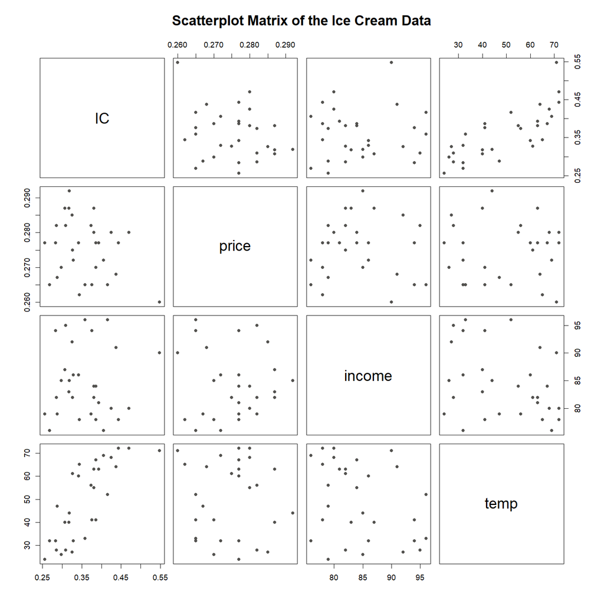

Scatterplot matrix of the ice cream data

## 모형: 식에 재료를 더한다

$$y_i=\beta_0+\beta_1 x_{i1}+\beta_2 x_{i2}+\cdots+\beta_p x_{ip}+\varepsilon_i,\qquad i=1,\dots,n$$

여기서 $y_i$는 $i$번째 반응변수(아이스크림 소비량), $x_{i1},\dots,x_{ip}$는 $i$번째 관측의 설명변수 값(가격·소득·온도이면 $p=3$), $\beta_0$은 절편, $\beta_1,\dots,\beta_p$는 각 설명변수의 회귀계수, $\varepsilon_i$는 평균 0·분산 $\sigma^2$인 오차, $n$은 관측 수(우리 자료는 30)입니다.

$$\mathbf{y}=\mathbf{X}\boldsymbol{\beta}+\boldsymbol{\varepsilon},\qquad \hat{\boldsymbol\beta}=(\mathbf X^\top\mathbf X)^{-1}\mathbf X^\top\mathbf y$$

여기서 $\mathbf{y}$는 반응변수 $n$개를 쌓은 벡터, $\mathbf{X}$는 절편용 1과 설명변수들을 열로 묶은 행렬, $\boldsymbol{\beta}$는 회귀계수 벡터, $\boldsymbol{\varepsilon}$는 오차 벡터이고, $\hat{\boldsymbol\beta}$는 최소제곱 추정량입니다.

- 유도 스케치: 잔차 제곱합을 $\boldsymbol\beta$로 미분해 0으로 놓으면(제3장 용수철이 멈추는 지점) 이 식이 나온다
- **한 줄 요약**: 변수가 몇 개든, 최소제곱 해는 행렬식 하나로 끝난다

Source: CNU regression lecture note; Kutner, Nachtsheim, Neter, Li (2005), *Applied Linear Statistical Models*, 5th ed.

## 계수 해석의 핵심: “다른 변수를 고정했을 때”

```r
# Fit the full model: consumption on price, income, and temperature
fit_full <- lm(IC ~ price + income + temp, data = ice)
summary(fit_full)   # coefficients, p-values, R-squared
```

$$\hat y_i = 0.193 - 1.029\,x_{i1} + 0.00331\,x_{i2} + 0.00346\,x_{i3}$$

여기서 $\hat y_i$는 적합값(예측 소비량), $x_{i1}$은 가격, $x_{i2}$는 소득, $x_{i3}$은 온도입니다.

Coefficient estimates of the full model (n = 30, $R^2$ = 0.719)

| Term | Estimate | p-value |
| --- | --- | --- |
| price ($x_{i1}$) | $-1.029$ | 0.226 |
| income ($x_{i2}$) | 0.00331 | 0.0090 |
| temp ($x_{i3}$) | 0.00346 | $3.0\times 10^{-8}$ |

- temp 계수 0.00346: **가격·소득을 고정한 채** 온도만 1도 오를 때의 평균 소비량 증가
- price는 $p = 0.226$: 이 자료에서는 가격 효과의 **증거가 부족** — “효과가 없다”는 증명이 아님

Computed by code/agent/2026-08-11/make-lecture-figures.R

## $R^2$는 공짜로 오른다 — 수정 $R^2$

- 설명변수를 **넣기만 하면** $R^2$는 절대 내려가지 않음 — 짐을 늘리면 항상 조금은 나아 보임
- 공짜 상승에 “변수 사용료”를 물린 점수가 수정 $R^2$ ($\bar R^2$)

$$\bar R^2 = 1-\frac{SSE/(n-p-1)}{SST/(n-1)}$$

여기서 $SSE=\sum_{i=1}^n e_i^2$는 잔차제곱합($e_i = y_i - \hat y_i$는 잔차), $SST=\sum_{i=1}^n (y_i-\bar y)^2$는 총제곱합($\bar y$는 $y$의 평균), $n$은 관측 수, $p$는 설명변수 개수입니다. $p$가 커지면 나누는 수 $n-p-1$이 작아져 벌점이 붙으므로, 쓸모없는 변수를 넣으면 $\bar R^2$는 오히려 내려갑니다.

$R^2$ before and after adding variables

| Model | $R^2$ | Adjusted $R^2$ |
| --- | --- | --- |
| IC ~ temp | 0.602 | 0.587 |
| IC ~ price + income + temp | 0.719 | 0.686 |

- **한 줄 요약**: 모형끼리 비교할 때는 $R^2$가 아니라 수정 $R^2$를 본다

Computed by code/agent/2026-08-11/make-lecture-figures.R

## 모형 전체가 쓸모 있는가: F-검정

- 개별 변수를 따지기 전에 먼저 묻기: “세 변수를 **다 합쳐도** 소용없는 것 아닐까?”
- 가설: $H_0:\ \beta_1=\beta_2=\cdots=\beta_p=0$ (모든 재료가 무의미) vs $H_1$: 적어도 하나는 $0$이 아님

$$F=\frac{SSR/p}{SSE/(n-p-1)}$$

여기서 $SSR=\sum_{i=1}^n(\hat y_i-\bar y)^2$는 회귀제곱합(모형이 설명한 부분), $SSE$는 잔차제곱합(설명하지 못한 부분), $p$는 설명변수 개수, $n$은 관측 수입니다. 설명한 부분이 설명 못 한 부분에 비해 충분히 크면 $F$가 커져 $H_0$를 기각합니다.

- 점검 순서: 계측 시스템 **전체 점검**(F-검정) 통과 후 **채널별 점검**(개별 t-검정)
- `summary(fit_full)` 출력 맨 아래 줄의 `F-statistic`이 바로 이 값
- **한 줄 요약**: F-검정은 모형이라는 팀 전체의 실력 테스트다
- **한 줄 요약**: 여러 원인을 한 모형에 — 계수는 “다른 변수 고정” 조건으로 읽는다

Source: CNU regression lecture note; Kutner, Nachtsheim, Neter, Li (2005), *Applied Linear Statistical Models*, 5th ed.

# 제5장 회귀진단 및 보정 — 숫자만 믿지 말고 그림을 보라

## 같은 숫자, 전혀 다른 그림 — Anscombe의 사중주

네 개의 서로 다른 자료에 회귀직선을 그었더니 **넷 다 똑같은 직선**이 나왔습니다.

$$\hat y_i = 3.00 + 0.500\,x_i$$

여기서 $\hat y_i$는 $i$번째 관측의 적합값(직선이 예측한 값), $x_i$는 설명변수 값, $3.00$은 절편 추정값 $\hat\beta_0$, $0.500$은 기울기 추정값 $\hat\beta_1$입니다.

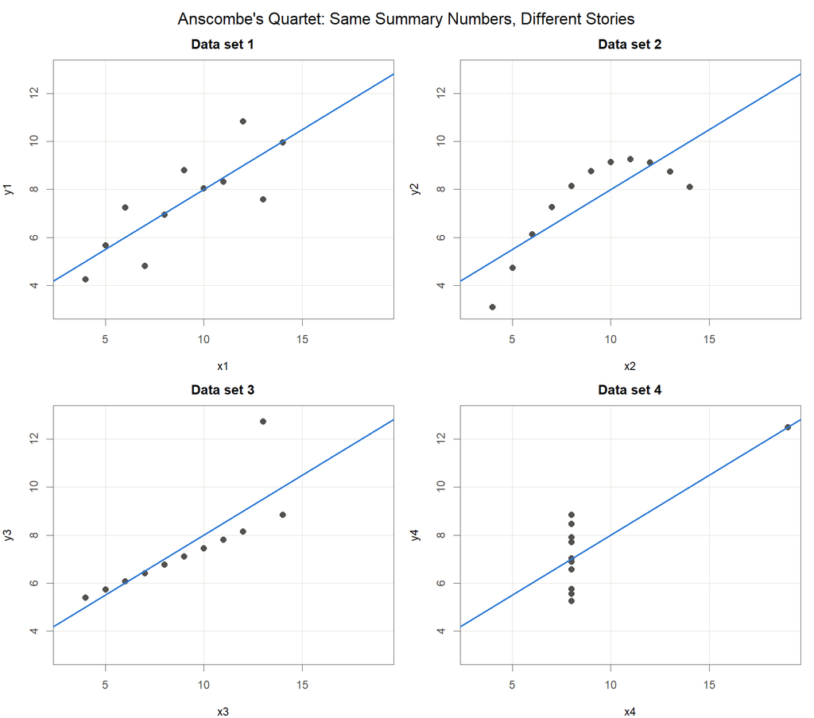

Anscombe’s quartet: identical summary statistics, very different data

- 요약 숫자만 보면 네 자료는 구분 불가 — 그림을 보면 전혀 다른 이야기 (Anscombe, 1973)

Fitted coefficients computed from base R `anscombe` data by code/agent/2026-08-11/make-lecture-figures.R

## 회귀모형이 앉는 의자, 다리는 4개

$$y_i = \beta_0 + \beta_1 x_{i1} + \cdots + \beta_p x_{ip} + \varepsilon_i, \qquad \varepsilon_i \overset{iid}{\sim} N(0,\ \sigma^2)$$

여기서 $y_i$는 반응변수, $x_{i1},\dots,x_{ip}$는 설명변수, $\beta_0,\dots,\beta_p$는 회귀계수, $\varepsilon_i$는 오차, $\sigma^2$은 오차의 분산이며, $iid$는 오차들이 서로 독립이고 같은 분포를 따른다는 뜻입니다.

- **선형성**: $x$와 $y$의 관계가 직선으로 표현됨
- **독립성**: 오차 $\varepsilon_i$끼리 서로 독립
- **정규성**: 오차가 정규분포 $N(0,\sigma^2)$을 따름
- **등분산성**: 오차의 분산이 어디서나 같은 $\sigma^2$
- 다리 하나만 부러져도 의자는 기우뚱 — 표준오차·검정·신뢰구간이 흔들림 (Kutner et al., 2005)

## 잔차 $e_i$ — 모형이 설명하지 못한 나머지

$$e_i = y_i - \hat y_i$$

여기서 $y_i$는 실제 관측값, $\hat y_i$는 모형의 적합값, $e_i$는 둘의 차이인 잔차입니다.

- 오차 $\varepsilon_i$는 볼 수 없지만, 잔차 $e_i$는 자료에서 계산되는 **오차의 발자국**
- 가정이 모두 맞으면 잔차는 0 주위에 **패턴 없이** 흩어져야 함
- 잔차 그림 = 모형의 **청진기**: 겉(요약 숫자)이 멀쩡해도 속은 들어봐야 함

```r
# Fit the ice cream model and draw the 4 standard diagnostic plots
fit <- lm(IC ~ income + temp, data = ice)
par(mfrow = c(2, 2))   # 2 x 2 panel layout
plot(fit)              # residual diagnostics in one command
```

## 진단 그림 4종 세트 읽는 법

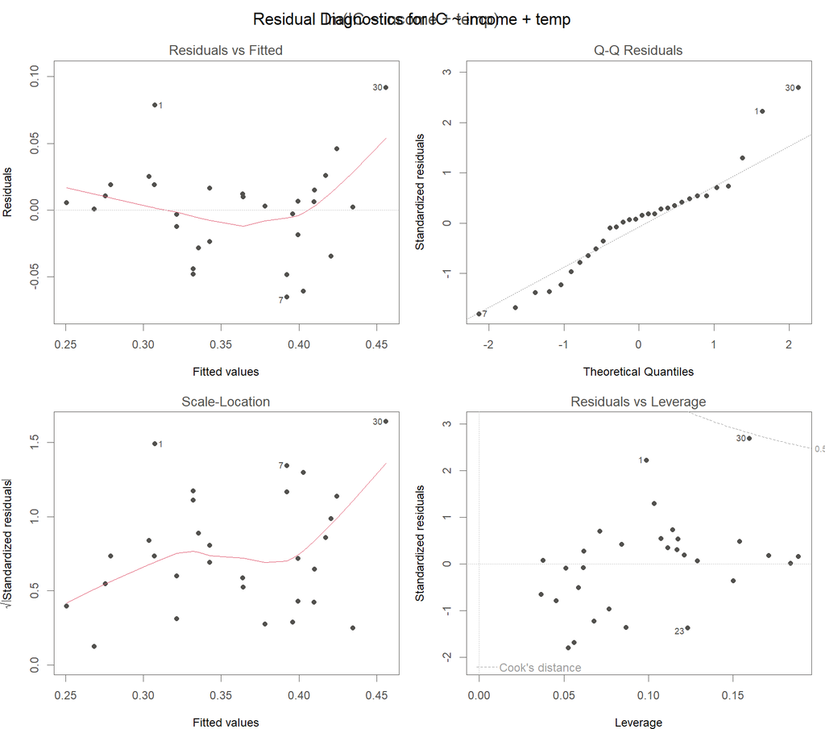

Residual diagnostics for IC ~ income + temp

- **좌상 Residuals vs Fitted**: 곡선 패턴이 보이면 → 선형성 위반 신호
- **우상 Normal Q-Q**: 점들이 대각선에서 크게 이탈하면 → 정규성 의심
- **좌하 Scale-Location**: 오른쪽으로 갈수록 깔때기처럼 퍼지면 → 등분산성 위반
- **우하 Residuals vs Leverage**: 오른쪽 구석의 외딴 점 → 영향점 후보

## 이상치·지렛값·영향점 — 시소 끝에 앉은 아이

- **이상치(outlier)**: $y$ 방향으로 동떨어진 점 — 잔차가 큰 점
- **지렛값(leverage) $h_{ii}$**: $x$ 방향으로 얼마나 끝자리인지 — 시소의 끝일수록 큼
- **영향점(influential point)**: 그 한 점을 빼면 회귀직선이 크게 움직이는 점
- 시소 비유: 끝에 앉은 아이(큰 지렛값)가 힘껏 누르면(큰 잔차) 시소 전체가 기울어짐

$$D_i = \frac{r_i^2}{p+1}\cdot\frac{h_{ii}}{1-h_{ii}}$$

여기서 $r_i$는 $i$번째 표준화잔차(잔차 $e_i$를 그 표준오차로 나눈 값), $h_{ii}$는 $i$번째 관측의 지렛값, $p+1$은 절편을 포함한 회귀계수의 개수입니다. $D_i$가 유난히 큰 점이 영향점 후보입니다 (Cook, 1977).

## 다중공선성과 VIF — 설명변수끼리 겹치면

- 발표자 두 명이 **같은 내용을 동시에 말하면** 누구 말인지 구분 어려움 → 설명변수끼리 정보가 겹치면 $\hat\beta_j$ 추정이 불안정

$$\mathrm{VIF}_j = \frac{1}{1-R_j^2}$$

여기서 $R_j^2$는 $j$번째 설명변수를 **나머지 설명변수들로 회귀**했을 때의 결정계수입니다. 겹침이 없으면 $\mathrm{VIF}_j$는 1, 겹침이 심해 $R_j^2$가 1에 가까워질수록 커집니다.

VIF for the full model lm(IC ~ price + income + temp)

| Variable | VIF |
| --- | --- |
| price | 1.03 |
| income | 1.14 |
| temp | 1.14 |

- 관례적으로 VIF가 10(문헌에 따라 5)을 넘으면 심각한 다중공선성을 의심 (Kutner et al., 2005) — 아이스크림 자료는 모두 1에 가까워 **문제 없음**

```r
# VIF by hand: regress one predictor on the remaining predictors
r2 <- summary(lm(price ~ income + temp, data = ice))$r.squared
1 / (1 - r2)   # VIF for price = 1.03
```

VIF computed by code/agent/2026-08-11/make-lecture-figures.R

## 진단 후 처방 — 보정 수단 개관

- **곡선 패턴(선형성 위반)** → 변수 변환($\log$, 제곱근) 또는 곡선 항 추가
- **깔때기 모양(등분산성 위반)** → 가중회귀(WLS)로 보정 — **제8장에서 자세히**
- **Q-Q 이탈(정규성 의심)** → 반응변수 변환 검토
- **이상 관측** → 먼저 **원인 조사**: 기록 오류인지, 진짜 신호인지 — 함부로 삭제 금지
- 한 줄 요약: **진단은 고장 신호, 보정은 정비** — 신호의 원인을 알고 고친다

# 제6장 모형 비교와 변수선택 — 필요한 짐만 싸기

## 비유: 여행 가방 싸기

- 짐을 **다 넣으면**: 가방이 무거워 끌고 다니기 힘듭니다 → 변수를 다 넣은 모형은 복잡하고, 해석과 관리가 어렵습니다
- 짐을 **너무 빼면**: 정작 필요한 옷이 없어 곤란합니다 → 중요한 변수를 빼면 설명력이 크게 떨어집니다
- 좋은 모형 = **설명력**(잘 맞음)과 **단순함**(가벼움)의 균형 (Kutner et al., 2005)
- 이 장의 질문: 아이스크림 판매량 예측에 `price`, `income`, `temp` 중 **무엇을 담을까?**

## 과적합: 기출문제만 통째로 외운 학생

- 기출문제 답만 통째로 외운 학생: 기출(훈련 자료)은 100점, **새 시험(새 자료)은 낙제**
- 변수를 추가하면 $R^2$(결정계수, 제3장)는 **절대 내려가지 않습니다** → “다 넣자”는 착각을 부릅니다 (Kutner et al., 2005)
- 자료 속 우연한 **잡음까지 외운** 모형 = **과적합(overfitting)** → 새 데이터 예측 실패
- 해결책: 짐(변수) 개수만큼 **벌점을 주는 성적표**가 필요 → 수정 $R^2$, AIC

## AIC: 성적에서 짐 개수만큼 벌점 빼기

$$\mathrm{AIC} = -2\log\hat{L} + 2k$$

여기서 $\hat{L}$은 적합한 모형이 자료를 얼마나 잘 설명하는지 나타내는 최대가능도(잘 맞을수록 커짐), $\log$는 자연로그, $p$는 설명변수의 개수, $k$는 추정하는 모수의 개수(회귀계수 $p+1$개 + 오차분산 $\sigma^2$ 1개 = $p+2$; R의 `AIC()`가 세는 방식)입니다.

- 앞 항 $-2\log\hat{L}$: **시험 점수** 부분 — 자료에 잘 맞을수록 작아집니다
- 뒤 항 $2k$: **벌점** 부분 — 추정하는 모수가 하나 늘 때마다 2점씩 더해집니다
- AIC는 **작을수록 좋은 모형**입니다 (Akaike, 1974)
- 수정 $R^2$(adjusted $R^2$)도 같은 정신: 변수 개수를 반영해 $R^2$를 깎아 줍니다

## 아이스크림 데이터: 세 후보 모형의 성적표

Candidate models for ice cream sales (n = 30)

| Model | $R^2$ | Adjusted $R^2$ | AIC |
| --- | --- | --- | --- |
| `IC ~ price + income + temp` (full) | 0.719 | 0.686 | -107.21 |
| `IC ~ income + temp` | 0.702 | 0.680 | **-107.48** |
| `IC ~ temp` | 0.602 | 0.587 | -100.77 |

```r
# Compare candidate models on the AIC scale (smaller is better)
full <- lm(IC ~ price + income + temp, data = ice)
AIC(full)                                   # -107.21
AIC(lm(IC ~ income + temp, data = ice))  # -107.48 <- smallest
AIC(lm(IC ~ temp, data = ice))           # -100.77
```

- AIC 최소 = `IC ~ income + temp` → **price는 가방에서 내려놓습니다**

Values computed by code/agent/2026-08-11/make-lecture-figures.R.

## step(): AIC 벌점으로 자동 짐 싸기

```r
# Backward elimination by AIC, starting from the full model
step(lm(IC ~ price + income + temp, data = ice))
# Start:                      AIC = -194.34
# - drop price  -> AIC = -194.62  (smaller: better -> remove price)
# - drop income -> AIC = -188.31  (larger: worse  -> keep income)
# - drop temp   -> AIC = -160.31  (larger: worse  -> keep temp)
# Final selected model: IC ~ income + temp
```

- `step()`은 변수를 하나씩 빼 보며 **AIC가 가장 작아지는 길**을 자동으로 찾습니다
- 결과: `price` 제거(-194.34 → -194.62), `income`·`temp`는 유지
- 손으로 만든 성적표(앞 슬라이드)와 **같은 결론**: `IC ~ income + temp`

Note: step() reports AIC up to an additive constant, so its values differ from AIC(); with the same data and the same n, the rankings are identical. Computed by code/agent/2026-08-11/make-lecture-figures.R.

## 주의: 자동 선택은 내비게이션일 뿐

- `step()`은 **후보를 제안**할 뿐, 최종 결정은 연구자의 몫입니다
- 선택된 모형에서 **잔차 진단을 반드시 다시** 합니다 (제5장의 도구)
- **도메인 지식이 우선**: 이론상 꼭 필요한 변수는 벌점 점수만으로 버리지 않습니다
- 계측기 비유: 자동 교정 기능이 있어도 **최종 확인은 사람**이 하듯이
- 한 줄 요약: **필요한 짐만 싸되, 꼭 필요한 짐은 두고 내리지 않기**

# 제7장 사례분석 — 아이스크림 데이터로 처음부터 끝까지

## 데이터와 두 개의 질문

- 자료: 4주 단위로 묶인 30개 기간의 판매 기록 (관측 수 $n = 30$)
- 질문 1 — 설명: 무엇이 아이스크림 소비를 움직이는가?
- 질문 2 — 예측: 다음 기간에는 얼마나 팔릴까?

Ice cream data: 30 four-week periods (CNU regression lecture note, Ch. 7)

| Variable | Meaning |
| --- | --- |
| IC | Per-capita ice cream consumption (pints) |
| price | Price of ice cream |
| income | Income |
| temp | Mean temperature (°F) |

## 1단계: 먼저 눈으로 본다

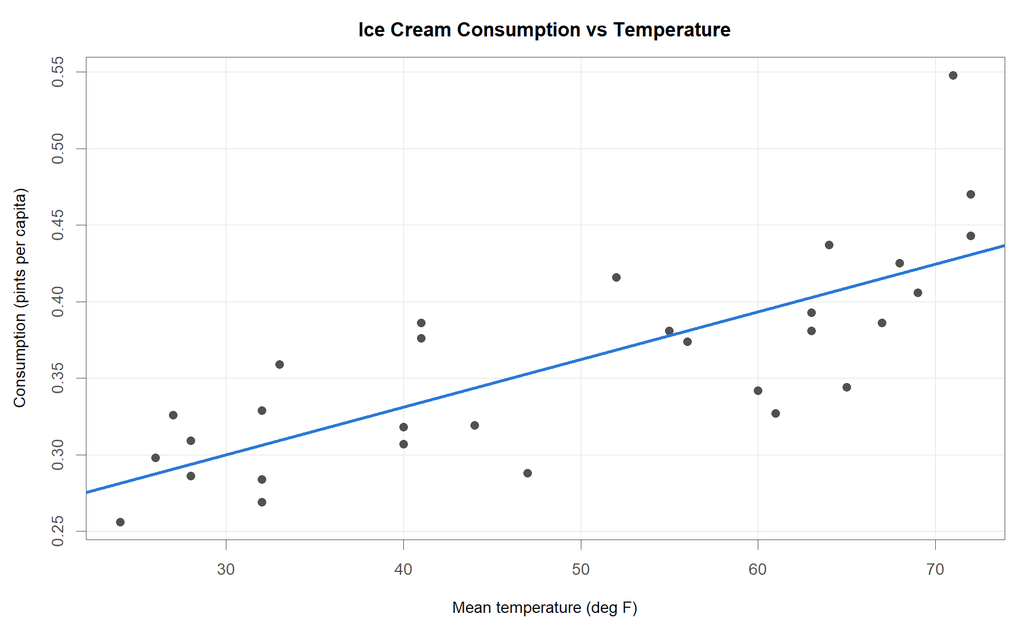

Ice cream consumption vs temperature with the fitted least-squares line

- 숫자 요약보다 그림이 먼저 — 요약통계가 같아도 그림은 전혀 다를 수 있음 (Anscombe, 1973)
- 온도가 오르면 소비가 늘어나는 우상향 경향이 뚜렷

## 2단계: 후보를 다 넣고 적합 — full model

```r
# Fit the full model with all three candidate predictors
full <- lm(IC ~ price + income + temp, data = ice)
summary(full)
```

$$\hat y_i = 0.193 - 1.029\,x_{i1} + 0.00331\,x_{i2} + 0.00346\,x_{i3}$$

여기서 $\hat y_i$는 $i$번째 기간 소비량(IC)의 적합값, $x_{i1}$은 가격(price), $x_{i2}$는 소득(income), $x_{i3}$은 온도(temp)입니다.

Full model fit, $R^2$ = 0.719, adjusted $R^2$ = 0.686, $n$ = 30 (computed by code/agent/2026-08-11/make-lecture-figures.R)

| Term | Estimate | p-value |
| --- | --- | --- |
| (Intercept) | 0.193 | — |
| price | -1.029 | 0.226 |
| income | 0.00331 | 0.0090 |
| temp | 0.00346 | 3.0e-08 |

- 온도·소득은 유의, 가격은 유의하지 않음 ($p = 0.226$)
- VIF: price 1.03, income 1.14, temp 1.14 → 다중공선성 걱정 없음

## 3단계: 변수선택 — step()이 고른 모형

```r
# Backward elimination by AIC; the selected model is kept in `reduced`
reduced <- step(full)
```

- step 경로: 시작 AIC $-194.34$ → price 제거 후 $-194.62$로 개선 (Akaike, 1974)
- income, temp를 빼면 각각 $-188.31$, $-160.31$로 악화 → 최종 모형은 IC ~ income + temp

Model comparison by AIC(); step() reports AIC on a scale shifted by a constant, so the ranking is identical (computed by code/agent/2026-08-11/make-lecture-figures.R)

| Model | AIC | $R^2$ | Adj. $R^2$ |
| --- | --- | --- | --- |
| IC ~ price + income + temp | -107.21 | 0.719 | 0.686 |
| IC ~ income + temp | -107.48 | 0.702 | 0.680 |
| IC ~ temp | -100.77 | 0.602 | 0.587 |

$$\hat y_i = -0.113 + 0.00353\,x_{i2} + 0.00354\,x_{i3}$$

여기서 $\hat y_i$는 소비량 적합값, $x_{i2}$는 소득, $x_{i3}$은 온도입니다. 소득이 같을 때 온도가 1도(°F) 오르면 평균 소비가 1인당 0.00354파인트 늘어나고($p = 1.5\times 10^{-8}$), 소득 효과도 유의합니다($p = 0.0055$).

## 4단계: 진단 — 모형의 건강검진

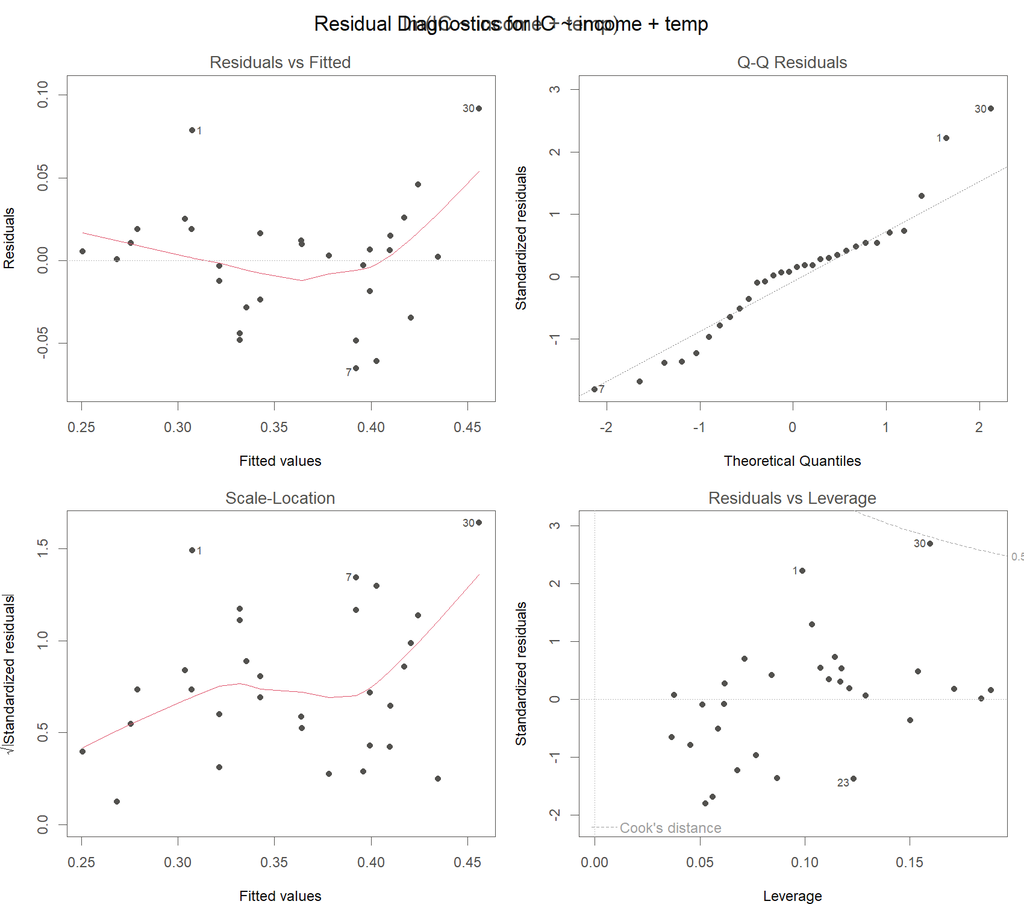

Residual diagnostics for IC ~ income + temp

잔차 $e_i = y_i - \hat y_i$를 봅니다. 여기서 $e_i$는 잔차, $y_i$는 실제 소비량, $\hat y_i$는 모형의 적합값입니다.

- 잔차 vs 적합값: 특별한 무늬 없이 흩어져 있는가
- Q-Q: 정규성 / Scale-Location: 등분산 / Leverage: 영향점 (Cook, 1977)
- 크게 벗어나는 관측은 원자료에서 원인을 확인하고 보고서에 명시

## 5단계: 평균 맞히기 vs 한 명 맞히기 — 신뢰구간과 예측구간

- 비유: “우리 반 평균 키 추정” vs “다음에 전학 올 학생 한 명의 키 맞히기”
- 평균은 개인차가 상쇄되어 좁게, 한 명은 개인차까지 떠안으므로 항상 더 넓게

평균 반응에 대한 신뢰구간과 새 관측에 대한 예측구간:

$$\hat y_0 \pm t_{\alpha/2,\;n-p-1}\sqrt{\widehat{\operatorname{Var}}(\hat y_0)}
\qquad \text{vs} \qquad
\hat y_0 \pm t_{\alpha/2,\;n-p-1}\sqrt{\widehat{\operatorname{Var}}(\hat y_0) + \hat\sigma^2}$$

여기서 $\hat y_0$는 새 조건에서 회귀식으로 계산한 값, $t_{\alpha/2,\,n-p-1}$은 자유도 $n-p-1$인 $t$분포의 분위수, $\widehat{\operatorname{Var}}(\hat y_0)$은 $\hat y_0$의 분산 추정값, $\hat\sigma^2$은 오차분산 $\sigma^2$의 추정값, $n$은 관측 수, $p$는 설명변수 개수입니다. 예측구간은 근호 안에 $\hat\sigma^2$이 더해지므로 항상 신뢰구간보다 넓습니다 (Kutner et al., 2005).

```r
# Interval for the AVERAGE of periods like this vs ONE specific next period
new <- data.frame(income = 85, temp = 65)
predict(reduced, new, interval = "confidence")   # narrower: mean response
predict(reduced, new, interval = "prediction")   # wider: one new observation
```

## 사례가 주는 교훈 — 다섯 단계 사이클

- 1 그림: 숫자보다 먼저 산점도 (Anscombe, 1973)
- 2 모형: 후보 변수를 넣어 적합
- 3 선택: AIC 등 기준으로 군더더기 제거
- 4 진단: 잔차 그림으로 가정 점검, 영향점 확인
- 5 보고: 계수의 뜻 + 구간(불확실성)까지 함께 제시

계측기 검교정 곡선을 만들 때도 이 다섯 단계는 그대로 적용됩니다.

# 제8장 일반화 가중회귀모형 — 믿을 만한 측정에 더 큰 발언권을

## 비유: 정밀도가 다른 저울 세 대

- 같은 시료 하나를 세 저울로 잰다: 정밀 분석저울, 주방 저울, 낡은 체중계
- 세 숫자를 그냥 산술평균? 상식은 “정밀한 저울의 말을 더 믿어라”
- 실험실도 마찬가지: 계측기마다 교정 성적서에 적힌 **측정 불확도**가 다름
- 회귀분석의 번역: 믿을 만한 관측값에 더 큰 **발언권** = 가중치 $w_i$
- 여기서 $w_i$는 $i$번째 관측값에 주는 가중치, 즉 발언권의 크기입니다

## 문제 제기: 퍼짐이 한결같지 않다면 — 이분산

- 지금까지의 약속(등분산): $\operatorname{Var}(\varepsilon_i)=\sigma^2$
- 약속이 깨진 상황(이분산): $\operatorname{Var}(\varepsilon_i)=\sigma_i^2$

여기서 $\varepsilon_i$는 $i$번째 관측의 오차, $\sigma^2$는 모든 관측에 공통인 오차 분산, $\sigma_i^2$는 관측마다 달라지는 오차 분산입니다.

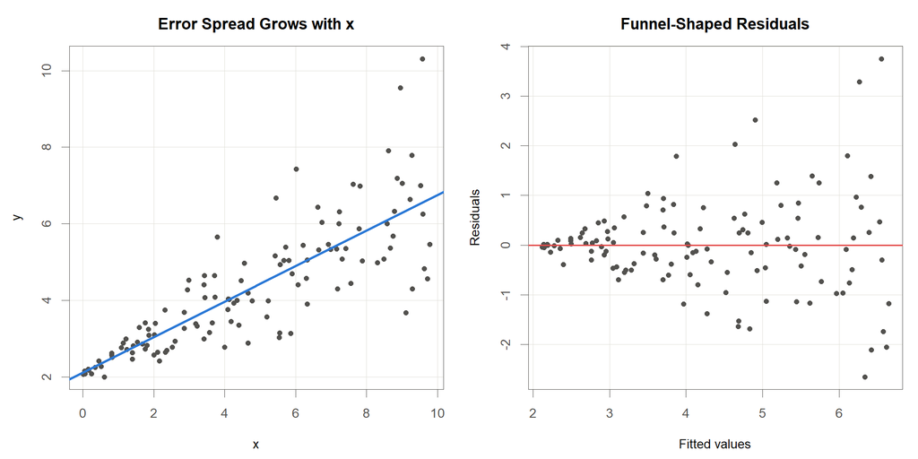

Simulated data with error spread growing in x (funnel-shaped residuals)

## 이분산에서 OLS(제3장에서 배운 보통최소제곱)의 운명

- 기울기 추정 $\hat\beta_1$은 여전히 **편향 없음** — 평균적으로는 과녁 중심을 맞힘
- 그러나 **최적(최소분산)이 아님** — 덜 흔들리는 더 좋은 추정법이 존재
- **표준오차는 왜곡됨** — 등분산을 전제로 계산된 공식이기 때문
- 그 결과 $t$-검정, $p$-값, 신뢰구간이 모두 틀어짐 (Kutner et al., 2005)
- 비유: 화살은 과녁 중심 주위에 떨어지지만, 흔들림이 크고 조준경 눈금(표준오차)마저 안 맞는 상태

여기서 $\hat\beta_1$은 기울기 $\beta_1$의 추정량입니다.

## WLS의 아이디어: 가중치를 붙인 최소제곱

$$\min_{\beta_0,\,\beta_1}\ \sum_{i=1}^{n} w_i\,\left(y_i-\beta_0-\beta_1 x_i\right)^2$$

여기서 $y_i$는 반응변수, $x_i$는 설명변수, $\beta_0,\beta_1$은 절편과 기울기, $w_i$는 $i$번째 관측의 가중치, $n$은 관측 수, $\sigma_i^2$는 $i$번째 관측의 오차 분산입니다.

- 분산이 작은(정밀한) 점에 큰 $w_i$: 이론적 최적 가중치는 $w_i = 1/\sigma_i^2$
- 모든 $w_i = 1$이면 그냥 OLS — 즉 **OLS는 WLS의 특수한 경우**

## 행렬로 쓰면 한 줄

$$\hat{\boldsymbol\beta}_W=(\mathbf X^\top \mathbf W \mathbf X)^{-1}\mathbf X^\top \mathbf W \mathbf y$$

여기서 $\mathbf y$는 반응변수 벡터, $\mathbf X$는 설명변수를 모은 모형행렬, $\mathbf W = \operatorname{diag}(w_1,\dots,w_n)$은 가중치를 대각선에 놓은 대각행렬, $\hat{\boldsymbol\beta}_W$는 가중최소제곱 추정량입니다.

- $\mathbf W = \mathbf I$(항등행렬)이면 앞에서 본 OLS 공식 $(\mathbf X^\top\mathbf X)^{-1}\mathbf X^\top\mathbf y$로 복귀
- 직관: $\mathbf W$는 각 관측의 발언권을 계산 전체에 심어 넣는 장치

## 실무 규칙: 가중치는 이렇게 정한다

Practical rules for choosing weights (Kutner et al., 2005; CNU lecture note Ch. 8)

| Situation | Weight $w_i$ |
| --- | --- |
| 측정 분산 $\sigma_i^2$를 아는 경우(교정 성적서, 반복 측정) | $w_i = 1/\sigma_i^2$ |
| $y_i$가 $n_i$개 측정값의 평균인 경우 | $w_i = n_i$ |
| 퍼짐(분산)이 $x_i$에 비례해 커지는 경우 | $w_i \propto 1/x_i$ |

여기서 $\sigma_i^2$는 $i$번째 관측의 오차 분산, $n_i$는 $y_i$를 만들 때 평균한 측정 횟수, $\propto$는 “비례한다”는 기호입니다.

- 공통 원리: **가중치 = 분산의 역수** — $n_i$개 평균의 분산은 $\sigma^2/n_i$이므로 역수를 취하면 $w_i \propto n_i$

## 예제: physics 자료 — 정밀한 점의 말을 들어주기

- physics 자료(CNU 강의노트 8장 예제 8.1, $n=10$): 측정 분산에 비례하는 값 $w$가 기록되어 있음 → 가중치는 역수 $1/w$

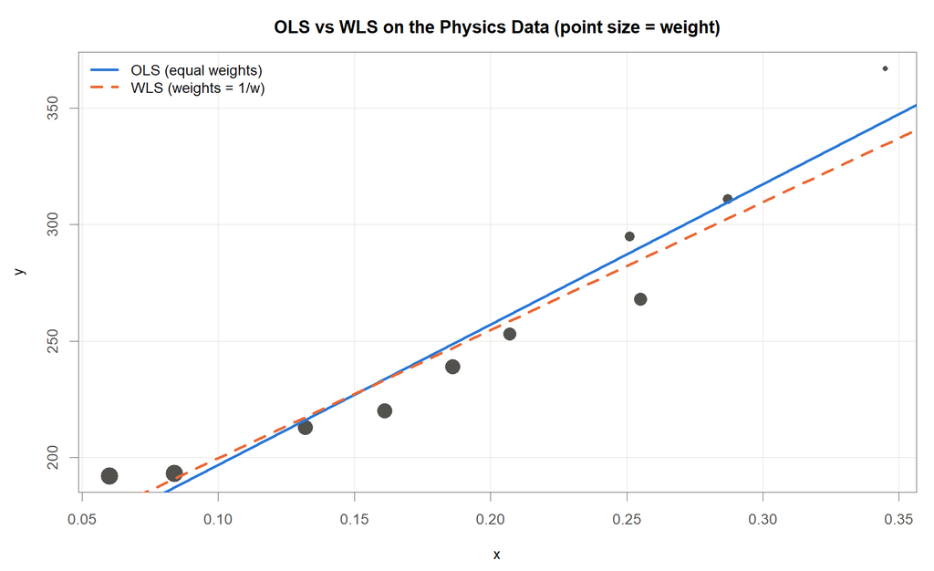

OLS vs WLS fits on the physics data; point size is proportional to weight

```r
# w is proportional to the measurement variance,
# so the weight is its inverse: 1/w
fit_ols <- lm(y ~ x, data = physics)
fit_wls <- lm(y ~ x, data = physics,
              weights = 1/w)
```

OLS vs WLS estimates on the physics data (n = 10)

| Estimate | OLS | WLS |
| --- | --- | --- |
| $\hat\beta_0$ (intercept) | 136.6 (SE 11.9) | 144.8 (SE 10.3) |
| $\hat\beta_1$ (slope) | 602.4 (SE 55.6) | 549.5 (SE 53.6) |

- 결과 읽기: 기울기 602.4 → 549.5로 이동, 표준오차는 두 계수 모두 감소(11.9 → 10.3, 55.6 → 53.6), WLS $R^2 = 0.929$

Computed by code/agent/2026-08-11/make-lecture-figures.R

## 한 걸음 더: 오차끼리 손잡고 움직인다면 — GLS

$$\hat{\boldsymbol\beta}_{GLS}=(\mathbf X^\top\boldsymbol\Sigma^{-1}\mathbf X)^{-1}\mathbf X^\top\boldsymbol\Sigma^{-1}\mathbf y$$

여기서 $\boldsymbol\Sigma$는 오차 벡터 $\boldsymbol\varepsilon$의 공분산행렬($\operatorname{Var}(\boldsymbol\varepsilon)=\boldsymbol\Sigma$)로, 대각 원소는 각 오차의 분산, 비대각 원소는 오차들 사이의 공분산입니다. 나머지 기호는 앞 슬라이드와 같습니다.

- WLS는 $\boldsymbol\Sigma$가 **대각행렬**인 특수한 경우 — 비대각(오차끼리의 상관)이 전부 0
- 시계열 자료의 자기상관: 어제의 오차와 오늘의 오차가 닮음 (CNU 강의노트 8장 예제 8.3, longley 자료)

```r
# Load nlme, which provides the gls() function
library(nlme)
# GLS with AR(1) errors over time on the longley data
fit_gls <- gls(Employed ~ GNP + Population, data = longley,
               correlation = corAR1(form = ~Year))
```

## 제8장 요약: 발언권을 공정하게

- 이분산이면 OLS는 편향은 없지만 **최적이 아니고, 표준오차가 틀어진다**
- 처방은 WLS: $\min\sum w_i(y_i-\beta_0-\beta_1 x_i)^2$, 이론적 최적 가중치는 $w_i = 1/\sigma_i^2$
- 실무 연결: **측정 불확도가 기록되어 있다면 그 분산의 역수를 `weights`로 반영하라**
- 오차끼리 상관까지 있으면 GLS: $\mathbf W$ 자리에 $\boldsymbol\Sigma^{-1}$
- 다음 장 예고: 아이스크림 가게로 돌아가 관측 연차 같은 범주 정보를 **가변수**로 넣는다

여기서 기호는 이 장에서 정의한 것과 같습니다($w_i$ 가중치, $\sigma_i^2$ 관측별 오차 분산, $\boldsymbol\Sigma$ 오차 공분산행렬).

# 제9장 가변수 회귀모형 — 범주를 스위치로 켜고 끄기

## 숫자가 아닌 정보를 모형에 넣으려면?

- 지금까지 쓴 설명변수: 온도, 가격, 소득 — 모두 **숫자**
- 현장의 중요한 정보는 범주인 경우가 많음: 관측 연차, 계측기 제조사, 운전/정지 상태
- 범주는 더하거나 곱할 수 없음 → 회귀식에 그대로 넣을 수 없음
- 해결: 전등 스위치처럼 **“해당하면 1, 아니면 0”** — 가변수(dummy variable)
- 아이스크림 데이터의 관측 연차 변수 `year`(0/1/2)로 직접 해 봅니다

## 스위치는 $k-1$개면 충분하다

Dummy coding for observation year (year): k = 3 categories need only k - 1 = 2 switches

| year (observation year) | $d_{1i}$ | $d_{2i}$ |
| --- | --- | --- |
| 0 (baseline) | 0 | 0 |
| 1 | 1 | 0 |
| 2 | 0 | 1 |

여기서 $d_{1i}$는 $i$번째 기간의 관측 연차가 year = 1이면 1, 아니면 0인 가변수이고, $d_{2i}$는 관측 연차가 year = 2이면 1, 아니면 0인 가변수입니다.

- 범주가 $k$개면 가변수는 $k-1$개: `year`는 3개 범주 → 스위치 2개
- 스위치가 모두 꺼진 상태가 **기준 범주**(여기서는 year = 0) — 그 몫은 절편 $\beta_0$가 담당
- 셋 다 넣으면 안 되는 이유: 어느 관측치든 $d_{0i}+d_{1i}+d_{2i}=1$ → 절편과 **완전 공선성**(dummy trap)
- 여기서 $d_{0i}$는 year = 0이면 1, 아니면 0인 (실제로는 만들지 않은) 세 번째 스위치입니다
- R에서는 `factor(year)`라고만 쓰면 이 코딩을 자동으로 만들어 줌

## 평행선 모형 — 기울기 하나, 절편 셋

$$y_i = \beta_0 + \beta_1 x_i + \beta_2 d_{1i} + \beta_3 d_{2i} + \varepsilon_i$$

여기서 $y_i$는 $i$번째 기간의 아이스크림 소비량(IC), $x_i$는 온도(temp), $d_{1i}, d_{2i}$는 각각 관측 연차가 year = 1, year = 2일 때 1이 되는 가변수, $\beta_0$는 기준 연차(year = 0)의 절편, $\beta_1$은 세 연차가 공유하는 온도의 기울기, $\beta_2, \beta_3$는 year = 1, year = 2 연차가 기준 연차보다 위아래로 얼마나 이동하는지 나타내는 절편 차이, $\varepsilon_i$는 평균 0, 분산 $\sigma^2$인 오차입니다.

- 연차별 절편: year = 0은 $\beta_0$, year = 1은 $\beta_0+\beta_2$, year = 2는 $\beta_0+\beta_3$
- 기울기 $\beta_1$은 공통 → 스위치는 직선을 **위아래로 평행이동**만 시킴

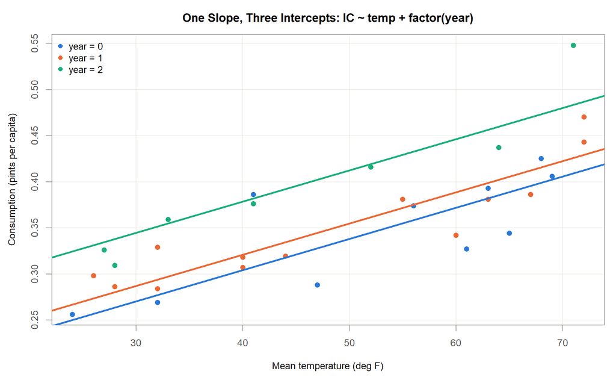

One common slope, three intercepts: IC ~ temp + factor(year)

Additive dummy-variable model; see Kutner et al. (2005) and the CNU regression lecture notes.

## R 결과 읽기 — 온도를 고정해도 관측 연차 효과가 남는다

```r
# Fit the parallel-lines model: common temp slope, observation-year-specific intercepts
fit_dummy <- lm(IC ~ temp + factor(year), data = ice)
summary(fit_dummy)
```

Coefficients of IC ~ temp + factor(year); R-squared = 0.790, adjusted R-squared = 0.765, n = 30 (computed by code/agent/2026-08-11/make-lecture-figures.R)

| Term | Estimate | p-value |
| --- | --- | --- |
| (Intercept) | 0.1687 | — |
| temp | 0.00339 | 1.0e-09 |
| factor(year)1 | 0.0165 | 0.232 |
| factor(year)2 | 0.0743 | 8.2e-05 |

- 같은 온도라도 3년차(year = 2)에는 평균 소비가 **+0.0743** 높음 — 시간에 따른 소비 수준의 상승 ($p = 8.2\times10^{-5} < 0.001$)
- year = 1의 차이 +0.0165는 유의하지 않음 ($p = 0.232$)
- 연차별 절편: $0.1687$, $0.1687+0.0165=0.1852$, $0.1687+0.0743=0.2430$
- 온도만 쓴 모형의 $R^2 = 0.602$ → 연차 스위치 추가 후 $R^2 = 0.790$ (adj. $0.587 \to 0.765$)

## 확장 — 기울기도 다르게: 상호작용

- 평행선 모형의 숨은 가정: 관측 연차는 **절편만** 바꾼다(온도 민감도는 세 연차가 동일)
- 기울기도 다를 수 있다면 $x_i \times d_{1i}$처럼 **곱한 항(상호작용)**을 추가

$$y_i = \beta_0 + \beta_1 x_i + \beta_2 d_{1i} + \beta_3 d_{2i} + \beta_4 x_i d_{1i} + \beta_5 x_i d_{2i} + \varepsilon_i$$

여기서 $x_i d_{1i}, x_i d_{2i}$는 온도와 연차 가변수를 곱한 상호작용 항이고, $\beta_4, \beta_5$는 year = 1, year = 2 연차에서 기울기가 기준 연차보다 얼마나 달라지는지 나타냅니다. 예를 들어 year = 1 연차의 기울기는 $\beta_1 + \beta_4$가 됩니다. 나머지 기호는 앞 슬라이드와 같습니다.

- R에서는 `lm(IC ~ temp * factor(year))` 한 줄이면 됨 (오늘은 개념까지만)
- 검교정 비유: 제조사마다 **영점**만 다르면 평행선 모형, **감도**까지 다르면 상호작용 모형

> **한 줄 요약**: 범주 정보는 0/1 스위치(가변수) $k-1$개로 모형에 들어간다. 스위치는 절편을 바꾸고(평행선 모형), $x$와 곱해 넣으면 기울기까지 바꾼다(상호작용 모형).

# 마무리 — 오늘의 지도 접기

## 전체 요약 — 공식 다섯 개로 그리는 지도

**1. 최소제곱 목적함수** — 점과 직선 사이 세로 거리 제곱합을 가장 작게

$$Q(\beta_0,\beta_1)=\sum_{i=1}^{n}\left(y_i-\beta_0-\beta_1 x_i\right)^2$$

**2. 최소제곱(OLS) 해** — 자료가 알려주는 최적의 계수

$$\hat{\boldsymbol{\beta}}=(\mathbf{X}^\top \mathbf{X})^{-1}\mathbf{X}^\top \mathbf{y}$$

**3. 결정계수** — 직선이 설명한 변동의 비율

$$R^2 = 1-\frac{\sum_{i=1}^{n} e_i^2}{\sum_{i=1}^{n}\left(y_i-\bar{y}\right)^2}$$

**4. 가중최소제곱(WLS) 해** — 정밀한 측정에 더 큰 발언권

$$\hat{\boldsymbol{\beta}}_{W}=(\mathbf{X}^\top \mathbf{W} \mathbf{X})^{-1}\mathbf{X}^\top \mathbf{W} \mathbf{y}$$

**5. AIC** — 설명력과 단순함의 저울 (Akaike, 1974)

$$\mathrm{AIC}=-2\log L + 2k$$

기호는 각 장에서 정의한 것과 같습니다.

## 내일부터 쓰는 실무 체크리스트

- **하나** — 모형을 적합하기 전에 **그림부터** 본다: 요약 수치가 같아도 자료 모양은 전혀 다를 수 있다 (Anscombe, 1973)
- **둘** — 다중회귀 계수는 **“다른 변수를 고정했을 때”**의 효과로 읽는다
- **셋** — 적합 후 **진단 그림 4종**(잔차-적합값, Q-Q, 등분산, 영향점)을 확인한다 (Cook, 1977)
- **넷** — **변수선택을 했다면 다시 진단**한다: 모형이 바뀌면 잔차도 바뀐다
- **다섯** — 관측마다 **측정 불확도가 다르면 가중치**를 반영한다 (가중회귀, 제8장)

## 참고문헌

- Galton, F. (1886). Regression towards mediocrity in hereditary stature. *Journal of the Anthropological Institute*, 15, 246-263.
- Kutner, M. H., Nachtsheim, C. J., Neter, J., & Li, W. (2005). *Applied Linear Statistical Models*, 5th ed. McGraw-Hill.
- Faraway, J. J. (2015). *Linear Models with R*, 2nd ed. CRC Press.
- Akaike, H. (1974). A new look at the statistical model identification. *IEEE Transactions on Automatic Control*, 19(6), 716-723.
- Anscombe, F. J. (1973). Graphs in statistical analysis. *The American Statistician*, 27(1), 17-21.
- Cook, R. D. (1977). Detection of influential observation in linear regression. *Technometrics*, 19(1), 15-18.
- CNU 회귀분석 강의노트 (본 특강의 뼈대 교재, 프로젝트 references 폴더)